# 241102_ProteomicsModels

## Elastic net cox regression

This is less sensitive to noise & overfitting. alpha = 1 for lasso, alpha = 0 for ridge

Ridge (L2), alpha = 0: Useful when you suspect all variables may be relevant but need regularization. Lasso (L1), alpha = 1: Helps with feature selection by pushing less informative coefficients to zero, simplifying the model.

Test the code

```r
outcome <- outcomes[1]

# Define the formula
formula_model_small <- as.formula(paste("Surv(time, status) ~", paste(c(clinicalpredictors, proteomic_selection), collapse = " + ")))

## Add CD6 and others for CD4 outcome, since these were not significant for CD4 outcome
if ("CD6" %notin% colnames(train[[outcome]])){
  dataset_train <- train[[outcome]] %>% filter(!is.na(status)) %>% left_join(
    train[["VL4K"]] %>% select(ID, CD6, SH2D1A, CNGB3), by = "ID")
  dataset_test <- test[[outcome]] %>% filter(!is.na(status)) %>% left_join(
    test[["VL4K"]] %>% select(ID, CD6, SH2D1A, CNGB3), by = "ID")
}else{
  dataset_train <- train[[outcome]]
  dataset_test <- test[[outcome]]
}

penalizedmodel_lasso <- GLMnet(formula_model_small, data = dataset_train, alpha = 1, lambda = NULL, cv = TRUE, nfolds = 10, standardize = TRUE)
```

Find optimal by crossvalidation

```r
# Define a sequence of alpha values to test
alpha_values <- seq(0, 1, by = 0.1)  # Adjust step size as needed

# Initialize a data frame to store results
elasticnet_cvresults <- data.frame(alpha = numeric(), lambda_min = numeric(), cvm_min = numeric(), outcome = character())

for (outcome in outcomes){

  ## Add CD6 and others for CD4 outcome, since these were not significant for CD4 outcome
  if ("CD6" %notin% colnames(train[[outcome]])){
    dataset_train <- train[[outcome]] %>% filter(!is.na(status)) %>% left_join(
      train[["VL4K"]] %>% select(ID, CD6, SH2D1A, CNGB3), by = "ID")
    dataset_test <- test[[outcome]] %>% filter(!is.na(status)) %>% left_join(
      test[["VL4K"]] %>% select(ID, CD6, SH2D1A, CNGB3), by = "ID")
  }else{
    dataset_train <- train[[outcome]]
    dataset_test <- test[[outcome]]
  }

  # Loop through each alpha value
  for (alpha in alpha_values) {
    # Perform cross-validation for each alpha
    set.seed(123)  # For reproducibility

    penalizedmodel_balanced <- GLMnet(formula_model_small, data = dataset_train, alpha = alpha, lambda = NULL, cv = TRUE, nfolds = 10, standardize = TRUE)

    # Store the results: best lambda and corresponding CV error
    elasticnet_cvresults <- rbind(
      elasticnet_cvresults,
      data.frame(alpha = alpha,
                 lambda_min = penalizedmodel_balanced$fit$lambda.min,
                 cvm_min = min(penalizedmodel_balanced$fit$cvm),
                 outcome = outcome))
  }
}
elasticnet_cvresults
```

```
##    alpha lambda_min  cvm_min outcome
## 1    0.0 0.30056716 9.014863    VL4K
## 2    0.1 0.19775312 9.043605    VL4K
## 3    0.2 0.15743945 9.063697    VL4K
## 4    0.3 0.16712541 9.071785    VL4K
## 5    0.4 0.12534406 9.078849    VL4K
## 6    0.5 0.11005196 9.083075    VL4K
## 7    0.6 0.10065158 9.087515    VL4K
## 8    0.7 0.08627278 9.091735    VL4K
## 9    0.8 0.07548868 9.097622    VL4K
## 10   0.9 0.06710105 9.104783    VL4K
## 11   1.0 0.06039095 9.111855    VL4K
## 12   0.0 0.57369919 9.550285  HYBRID
## 13   0.1 0.34392363 9.552928  HYBRID
## 14   0.2 0.20712861 9.562385  HYBRID
```

[output cut: 19 more lines]

```r
# Find the optimal alpha based on minimum CV error
optimal_alpha_value <- elasticnet_cvresults %>% group_by(outcome) %>% filter(cvm_min == min(cvm_min)) %>% select(alpha, outcome) %>%  pull(alpha, outcome)

print(paste0('optimal alpha for glmnet: ',optimal_alpha_value))
```

```
## [1] "optimal alpha for glmnet: 0" "optimal alpha for glmnet: 0"
## [3] "optimal alpha for glmnet: 0"
```

Try both prefiltered features and full featurelist

```r
outcome <- outcomes[1]

  ## Add CD6 and others for CD4 outcome, since these were not significant for CD4 outcome
  if ("CD6" %notin% colnames(train[[outcome]])){
    dataset_train <- train[[outcome]] %>% filter(!is.na(status)) %>% left_join(
      train[["VL4K"]] %>% select(ID, CD6, SH2D1A, CNGB3), by = "ID")
    dataset_test <- test[[outcome]] %>% filter(!is.na(status)) %>% left_join(
      test[["VL4K"]] %>% select(ID, CD6, SH2D1A, CNGB3), by = "ID")
  }else{
    dataset_train <- train[[outcome]]
    dataset_test <- test[[outcome]]
  }

penalizedmodel_lasso <- GLMnet(formula_model_small, data = dataset_train, alpha = 0, lambda = NULL, cv = TRUE, nfolds = 10, standardize = TRUE)

times <- seq(2, 8) * 365
survformula <- as.formula(paste("Surv(time, status) ~ 1"))
score_result <- Score(list("Penalized" = penalizedmodel_lasso),
        formula = survformula,
        data = dataset_test,
        metrics = "auc",
        summary = "risks",
        times = times)
AUC_overtime <- score_result$AUC$score
AUC_overtime$type <- "test"
print(AUC_overtime)
```

```
##        model times       AUC         se     lower     upper   type
##       <fctr> <num>     <num>      <num>     <num>     <num> <char>
## 1: Penalized   730 0.9242512 0.04885052 0.8285059 1.0000000   test
## 2: Penalized  1095 0.9242512 0.04885052 0.8285059 1.0000000   test
## 3: Penalized  1460 0.8926689 0.07700182 0.7417481 1.0000000   test
## 4: Penalized  1825 0.7624060 0.09748880 0.5713315 0.9534805   test
## 5: Penalized  2190 0.7639930 0.10217254 0.5637385 0.9642475   test
## 6: Penalized  2555 0.7459324 0.13071135 0.4897428 1.0000000   test
## 7: Penalized  2920 0.7108455 0.15080015 0.4152827 1.0000000   test
```

```r
features <- train[[outcome]] %>% select(-c(time, status, ID)) %>% colnames()
formula_model <- as.formula(paste("Surv(time, status) ~", paste(features, collapse = " + ")))

penalizedmodel_lasso <- GLMnet(formula_model, data = dataset_train, alpha = 1, lambda = NULL, cv = TRUE, nfolds = 10, standardize = TRUE)

times <- seq(2, 8) * 365
survformula <- as.formula(paste("Surv(time, status) ~ 1"))
score_result <- Score(list("Penalized" = penalizedmodel_lasso),
        formula = survformula,
        data = dataset_test,
        metrics = "auc",
        summary = "risks",
        times = times)
AUC_overtime <- score_result$AUC$score
AUC_overtime$type <- "test"
print(AUC_overtime)
```

```
##        model times       AUC         se     lower upper   type
##       <fctr> <num>     <num>      <num>     <num> <num> <char>
## 1: Penalized   730 0.8813364 0.06127681 0.7612361     1   test
## 2: Penalized  1095 0.8813364 0.06127681 0.7612361     1   test
## 3: Penalized  1460 0.8632370 0.08435961 0.6978952     1   test
## 4: Penalized  1825 0.8621437 0.07052550 0.7239162     1   test
## 5: Penalized  2190 0.8572933 0.07810282 0.7042146     1   test
## 6: Penalized  2555 0.9326299 0.06119365 0.8126925     1   test
## 7: Penalized  2920 0.9056818 0.08258420 0.7438198     1   test
```

## Gradient boosted machines

The disadvantage of using gbm() with Score() is that the formula in gbm() must be typed statically, which is very long in this case.

```r
outcome <- outcomes[1]

features <- train[[outcome]] %>% select(-c(time, status, ID)) %>% colnames()
formula_model <- as.formula(paste("Surv(time, status) ~", paste(features, collapse = " + ")))

formula_model
```

```
## Surv(time, status) ~ MALESEX + baseVL_log10 + AGE + baseCD4_sqrt +
##     GZMH + ITGB1BP2 + ADH4 + EPHX2 + ADAMTS16 + CA5A + ACOX1 +
##     MCFD2 + FCRL1 + ADGRG2 + ROR1 + CA13 + CCDC80 + SFTPD + PRKAR1A +
##     CDHR5 + IL6ST + GDF2 + NTRK2 + LGALS1 + CDH6 + ADAMTS13 +
##     ICAM3 + SELE + CCN3 + LILRB2 + ITGB2 + AMY2A + SEMA7A + XG +
##     ADGRE5 + PDGFRB + NCAM1 + OSMR + RARRES2 + NRP1 + ADA2 +
##     IGFBP3 + DPP4 + HSPG2 + ENAH + IL17A + IL5 + IL12RB1 + MICB_MICA +
##     BID + SCRN1 + PTH1R + ANXA11 + SLAMF7 + IL32 + RAB6A + ITGA6 +
##     FCRL6 + SULT2A1 + SH2D1A + KLRB1 + PRDX5 + KLRD1 + CD79B +
##     FCRL2 + ADAM23 + CD40LG + IDS + GZMA + CD6 + CD160 + LY9 +
##     MZB1 + ENPP5 + CD58 + HSPA1A + CD48 + CCL4 + CXCL10 + CCL17 +
##     CXCL9 + TNFRSF13B + CXCL3 + CCL24 + LGALS9 + CD276 + MEGF10 +
##     ADGRE2 + CCL22 + PRELP + CA11 + ADCYAP1R1 + NTF4 + NPTN +
##     GFER + NAMPT + SUGT1 + FCGR2B + GSTA3 + LTBP3 + FCRLB + RAD23B +
##     PSRC1 + HGS + ABL1 + TBC1D23 + MPI + GFRA2 + CALB1 + CDKN1A +
##     KAZALD1 + IGF1R + CDNF + KLK13 + USO1 + RBP5 + VAT1 + CDKN2D +
##     CD207 + DDAH1 + LAG3 + CBLN4 + PDCD1 + RTN4R + FXN + ITGB7 +
##     CD5 + PRDX6 + METAP2 + ITGAV + CLMP + DAB2 + CD27 + PPY +
##     C4BPB + ATOX1 + FGFBP1 + ITGB5 + KLB + TST + C19orf12 + CRADD +
##     PPP3R1 + ABHD14B + TNFRSF9 + FLRT2 + ASGR1 + GGT5 + ADAM22 +
##     CRTAM + CHMP1A + FKBP4 + ROBO2 + SCARF2 + LAMP2 + CD8A +
##     CXCL13 + TNFRSF8 + THY1 + CTSS + NTRK3 + SCARA5 + CGA + SPINK5 +
##     WARS + IL17RA + NCAM2 + CNTN4 + CD99L2 + CD99 + FCRL5 + NOP56 +
##     EXOSC10 + CSF2 + CD2 + SHD + IGHMBP2 + C1GALT1C1 + SIGLEC8 +
##     CCER2 + HSBP1 + KHK + NIT1 + GATD3 + ASPN + NIT2 + NGFR +
##     BPIFB2 + PGD + RAB27B + LCP1 + COL15A1 + PTPRC + POSTN +
##     LATS1 + TNFSF9 + KLRF1 + PTP4A3 + C1QL2 + AKAP12 + SCGB3A1 +
##     ADH1B + C1QTNF9 + RIDA + CD72 + GHR + TNFRSF17 + NEXN + C9 +
##     F10 + AHSG + AMY1A_AMY1B_AMY1C + B2M + SERPINA5 + IGLC2 +
##     C1R + C1S + ORM1 + C3 + DNLZ + CNGB3 + TMCO5A + ERC2 + CABP2 +
##     CAMLG + MDM1 + CLGN + EDF1 + RGCC + IDO1 + DSCAM + CDK5RAP3 +
##     STXBP1 + TSC22D1 + RGS10 + SUOX + LCN15 + DXO + PLXDC2 +
##     PNLIPRP1 + PLCB2 + KLRK1 + KIAA0319 + PALM2 + GSTT2B + DLG4 +
##     DHRS4L2 + MINK1 + TXNDC9 + PLSCR3 + VWA5A + LYZL2 + TIGIT +
##     REG3G + ZNRF4 + AMOTL2 + ACRBP + FAM171B + TADA3 + TARS1 +
##     CHCHD6 + AP3B1 + IFNAR1 + GPHA2 + NFU1
```

```r
formula_model_small
```

```
## Surv(time, status) ~ baseVL_log10 + baseCD4_sqrt + MALESEX +
##     AGE + ICAM3 + CD6 + LY9 + CRTAM + SH2D1A + C1QL2 + CNGB3
```

```r
## Add CD6 and others for CD4 outcome, since these were not significant for CD4 outcome
if ("CD6" %notin% colnames(train[[outcome]])){
  dataset_train <- train[[outcome]] %>% filter(!is.na(status)) %>% left_join(
    train[["VL4K"]] %>% select(ID, CD6, SH2D1A, CNGB3), by = "ID")
  dataset_test <- test[[outcome]] %>% filter(!is.na(status)) %>% left_join(
    test[["VL4K"]] %>% select(ID, CD6, SH2D1A, CNGB3), by = "ID")
}else{
  dataset_train <- train[[outcome]]
  dataset_test <- test[[outcome]]
}

# Fit a GBM model with survival data
gbm_model <- gbm(
    formula = Surv(time, status) ~
    MALESEX + baseVL_log10 + AGE + baseCD4_sqrt +
    GZMH + ITGB1BP2 + ADH4 + EPHX2 + ADAMTS16 + CA5A + ACOX1 +
    MCFD2 + FCRL1 + ADGRG2 + ROR1 + CA13 + CCDC80 + SFTPD + PRKAR1A +
    CDHR5 + IL6ST + GDF2 + NTRK2 + LGALS1 + CDH6 + ADAMTS13 +
    ICAM3 + SELE + CCN3 + LILRB2 + ITGB2 + AMY2A + SEMA7A + XG +
    ADGRE5 + PDGFRB + NCAM1 + OSMR + RARRES2 + NRP1 + ADA2 +
    IGFBP3 + DPP4 + HSPG2 + ENAH + IL17A + IL5 + IL12RB1 + MICB_MICA +
    BID + SCRN1 + PTH1R + ANXA11 + SLAMF7 + IL32 + RAB6A + ITGA6 +
    FCRL6 + SULT2A1 + SH2D1A + KLRB1 + PRDX5 + KLRD1 + CD79B +
    FCRL2 + ADAM23 + CD40LG + IDS + GZMA + CD6 + CD160 + LY9 +
    MZB1 + ENPP5 + CD58 + HSPA1A + CD48 + CCL4 + CXCL10 + CCL17 +
    CXCL9 + TNFRSF13B + CXCL3 + CCL24 + LGALS9 + CD276 + MEGF10 +
    ADGRE2 + CCL22 + PRELP + CA11 + ADCYAP1R1 + NTF4 + NPTN +
    GFER + NAMPT + SUGT1 + FCGR2B + GSTA3 + LTBP3 + FCRLB + RAD23B +
    PSRC1 + HGS + ABL1 + TBC1D23 + MPI + GFRA2 + CALB1 + CDKN1A +
    KAZALD1 + IGF1R + CDNF + KLK13 + USO1 + RBP5 + VAT1 + CDKN2D +
    CD207 + DDAH1 + LAG3 + CBLN4 + PDCD1 + RTN4R + FXN + ITGB7 +
    CD5 + PRDX6 + METAP2 + ITGAV + CLMP + DAB2 + CD27 + PPY +
    C4BPB + ATOX1 + FGFBP1 + ITGB5 + KLB + TST + C19orf12 + CRADD +
    PPP3R1 + ABHD14B + TNFRSF9 + FLRT2 + ASGR1 + GGT5 + ADAM22 +
    CRTAM + CHMP1A + FKBP4 + ROBO2 + SCARF2 + LAMP2 + CD8A +
    CXCL13 + TNFRSF8 + THY1 + CTSS + NTRK3 + SCARA5 + CGA + SPINK5 +
    WARS + IL17RA + NCAM2 + CNTN4 + CD99L2 + CD99 + FCRL5 + NOP56 +
    EXOSC10 + CSF2 + CD2 + SHD + IGHMBP2 + C1GALT1C1 + SIGLEC8 +
    CCER2 + HSBP1 + KHK + NIT1 + GATD3 + ASPN + NIT2 + NGFR +
    BPIFB2 + PGD + RAB27B + LCP1 + COL15A1 + PTPRC + POSTN +
    LATS1 + TNFSF9 + KLRF1 + PTP4A3 + C1QL2 + AKAP12 + SCGB3A1 +
    ADH1B + C1QTNF9 + RIDA + CD72 + GHR + TNFRSF17 + NEXN + C9 +
    F10 + AHSG + AMY1A_AMY1B_AMY1C + B2M + SERPINA5 + IGLC2 +
    C1R + C1S + ORM1 + C3 + DNLZ + CNGB3 + TMCO5A + ERC2 + CABP2 +
    CAMLG + MDM1 + CLGN + EDF1 + RGCC + IDO1 + DSCAM + CDK5RAP3 +
    STXBP1 + TSC22D1 + RGS10 + SUOX + LCN15 + DXO + PLXDC2 +
    PNLIPRP1 + PLCB2 + KLRK1 + KIAA0319 + PALM2 + GSTT2B + DLG4 +
    DHRS4L2 + MINK1 + TXNDC9 + PLSCR3 + VWA5A + LYZL2 + TIGIT +
    REG3G + ZNRF4 + AMOTL2 + ACRBP + FAM171B + TADA3 + TARS1 +
    CHCHD6 + AP3B1 + IFNAR1 + GPHA2 + NFU1,  # Survival formula
    data = dataset_train,
    distribution = "coxph",    # Cox model for survival
    n.trees = 1000,             # Number of trees
    interaction.depth = 3,     # Tree depth
    shrinkage = 0.01,          # Learning rate
    n.minobsinnode = 15,       # Minimum observations in terminal nodes
    bag.fraction = 0.5 # fraction of training data used for fitting, default 0.5
)

# Use Score function with the GBM survival model
times <- seq(2, 8) * 365
survformula <- as.formula(paste("Surv(time, status) ~ 1"))
score_result <- Score(
    list("GBM Model" = gbm_model),
    formula = survformula,   # Survival formula for Score function
    data = dataset_test,                        # Original data with survival info
    times = times,                # Time points to evaluate the survival model
    metrics = "AUC",                  # Metric for model evaluation
    summary = "risks"                     # Summary option for integrated Brier score
)

# Print results
AUC_overtime <- score_result$AUC$score
AUC_overtime$type <- "test"
print(AUC_overtime)
```

```
##        model times       AUC         se     lower     upper   type
##       <fctr> <num>     <num>      <num>     <num>     <num> <char>
## 1: GBM Model   730 0.9242512 0.04885052 0.8285059 1.0000000   test
## 2: GBM Model  1095 0.9242512 0.04885052 0.8285059 1.0000000   test
## 3: GBM Model  1460 0.8298516 0.10841409 0.6173639 1.0000000   test
## 4: GBM Model  1825 0.8406448 0.08232156 0.6792975 1.0000000   test
## 5: GBM Model  2190 0.8090041 0.09709632 0.6186988 0.9993094   test
## 6: GBM Model  2555 0.8632373 0.09934947 0.6685159 1.0000000   test
## 7: GBM Model  2920 0.8085322 0.13116946 0.5514448 1.0000000   test
```

## RSF model

Non-parametric machine learning approach.

The rfsrc() function offers many parameters for fine-tuning: * mtry: Number of variables randomly selected at each split * nodesize: Minimum size of terminal nodes * splitrule: Rule used for splitting nodes

```r
outcomes <- c("VL4K","HYBRID", "CD4")

outcome <- outcomes[1]

features <- train[[outcome]] %>% select(-c(time, status, ID)) %>% colnames()
formula_model <- as.formula(paste("Surv(time, status) ~", paste(features, collapse = " + ")))

## Add CD6 and others for CD4 outcome, since these were not significant for CD4 outcome
if ("CD6" %notin% colnames(train[[outcome]])){
  dataset_train <- train[[outcome]] %>% filter(!is.na(status)) %>% left_join(
    train[["VL4K"]] %>% select(ID, CD6, SH2D1A, CNGB3), by = "ID")
  dataset_test <- test[[outcome]] %>% filter(!is.na(status)) %>% left_join(
    test[["VL4K"]] %>% select(ID, CD6, SH2D1A, CNGB3), by = "ID")
}else{
  dataset_train <- train[[outcome]]
  dataset_test <- test[[outcome]]
}

rsfmodel <- rfsrc(formula_model, data = dataset_train, ntree = 3000, cv.fold = 10, nodesize = 15, mtry = 4, splitrule = "logrankscore", nsplit = 10)


times <- seq(2, 8) * 365
survformula <- as.formula(paste("Surv(time, status) ~ 1"))
score_result <- Score(list("RSF" = rsfmodel),
        formula = survformula,
        data = dataset_test,
        metrics = c("auc"),
        summary = "risks",
        times = times,
        plots = "ROC")

AUC_overtime <- score_result$AUC$score
AUC_overtime$type <- "test"
ROC_overtime <- score_result$ROC$plotframe
ROC_overtime$type <- "test"
AUCROC_overtime <- list(AUC_overtime = AUC_overtime, ROC_overtime = ROC_overtime)
print(AUCROC_overtime)
```

```
## $AUC_overtime
##     model times       AUC         se     lower     upper   type
##    <fctr> <num>     <num>      <num>     <num>     <num> <char>
## 1:    RSF   730 0.8692396 0.08994271 0.6929552 1.0000000   test
## 2:    RSF  1095 0.8582949 0.09816208 0.6659008 1.0000000   test
## 3:    RSF  1460 0.9133151 0.05326739 0.8089129 1.0000000   test
## 4:    RSF  1825 0.8126038 0.10122673 0.6142031 1.0000000   test
## 5:    RSF  2190 0.7760767 0.10109111 0.5779418 0.9742117   test
## 6:    RSF  2555 0.8110090 0.12285468 0.5702182 1.0000000   test
## 7:    RSF  2920 0.5171491 0.18453150 0.1554741 0.8788242   test
##
## $ROC_overtime
##       model times      risk       TPR        FPR   type
##      <fctr> <num>     <num>     <num>      <num> <char>
##   1:    RSF   730 0.1961419 0.0000000 0.03225806   test
##   2:    RSF   730 0.1856675 0.3303571 0.03225806   test
##   3:    RSF   730 0.1839387 0.3303571 0.03225806   test
##   4:    RSF   730 0.1741993 0.6607143 0.03225806   test
##   5:    RSF   730 0.1710977 0.6607143 0.06451613   test
##  ---
## 325:    RSF  2920 0.3749548 1.0000000 0.80000000   test
## 326:    RSF  2920 0.3629615 1.0000000 0.80000000   test
## 327:    RSF  2920 0.3594105 1.0000000 0.80000000   test
## 328:    RSF  2920 0.3575739 1.0000000 0.80000000   test
## 329:    RSF  2920 0.3552659 1.0000000 1.00000000   test
```

```r
AUC_overtime <- AUCROC_overtime$ROC_overtime

score_result$ROC$plotframe
```

```
##       model times      risk       TPR        FPR
##      <fctr> <num>     <num>     <num>      <num>
##   1:    RSF   730 0.1961419 0.0000000 0.03225806
##   2:    RSF   730 0.1856675 0.3303571 0.03225806
##   3:    RSF   730 0.1839387 0.3303571 0.03225806
##   4:    RSF   730 0.1741993 0.6607143 0.03225806
##   5:    RSF   730 0.1710977 0.6607143 0.06451613
##  ---
## 325:    RSF  2920 0.3749548 1.0000000 0.80000000
## 326:    RSF  2920 0.3629615 1.0000000 0.80000000
## 327:    RSF  2920 0.3594105 1.0000000 0.80000000
## 328:    RSF  2920 0.3575739 1.0000000 0.80000000
## 329:    RSF  2920 0.3552659 1.0000000 1.00000000
```

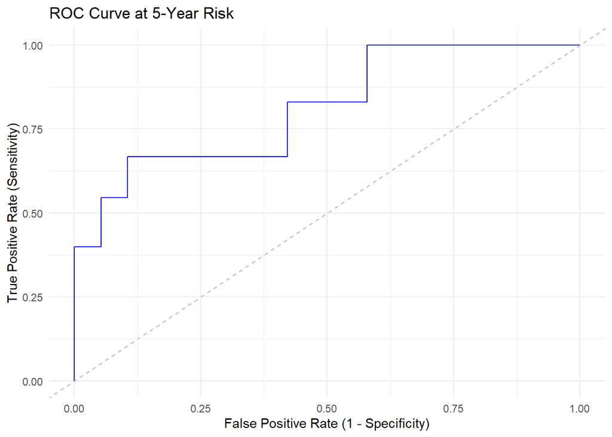

```r
roc_data_5yr <- subset(score_result$ROC$plotframe, times == 5*365)




# Plot using ggplot2
ggplot(roc_data_5yr, aes(x = FPR, y = TPR)) +
  geom_line(color = "blue") +
  geom_abline(slope = 1, intercept = 0, linetype = "dashed", color = "grey") +
  labs(
    title = "ROC Curve at 5-Year Risk",
    x = "False Positive Rate (1 - Specificity)",
    y = "True Positive Rate (Sensitivity)"
  ) +
  theme_minimal()
```

```r
AUC_overtime <- score_result$AUC$score
AUC_overtime$type <- "test"
print(AUC_overtime)
```

```
##     model times       AUC         se     lower     upper   type
##    <fctr> <num>     <num>      <num>     <num>     <num> <char>
## 1:    RSF   730 0.8692396 0.08994271 0.6929552 1.0000000   test
## 2:    RSF  1095 0.8582949 0.09816208 0.6659008 1.0000000   test
## 3:    RSF  1460 0.9133151 0.05326739 0.8089129 1.0000000   test
## 4:    RSF  1825 0.8126038 0.10122673 0.6142031 1.0000000   test
## 5:    RSF  2190 0.7760767 0.10109111 0.5779418 0.9742117   test
## 6:    RSF  2555 0.8110090 0.12285468 0.5702182 1.0000000   test
## 7:    RSF  2920 0.5171491 0.18453150 0.1554741 0.8788242   test
```

## Display the relevance of each predictor

```r
meandecreaseaccuracy = list()

obtain_meandecreaseaccuracy <- function(outcome){
  ## Add CD6 and others for CD4 outcome, since these were not significant for CD4 outcome
  if ("CD6" %notin% colnames(train[[outcome]])){
    dataset_train <- train[[outcome]] %>% filter(!is.na(status)) %>% left_join(
      train[["VL4K"]] %>% select(ID, CD6, SH2D1A, CNGB3), by = "ID")
    dataset_test <- test[[outcome]] %>% filter(!is.na(status)) %>% left_join(
      test[["VL4K"]] %>% select(ID, CD6, SH2D1A, CNGB3), by = "ID")
  }else{
    dataset_train <- train[[outcome]]
    dataset_test <- test[[outcome]]
  }

  # train the RSF, random survival forest
  features <- train[[outcome]] %>% select(-c(time, status, ID)) %>% colnames()
  formula_model <- as.formula(paste("Surv(time, status) ~", paste(features, collapse = " + ")))
  rsfmodel <- rfsrc(formula_model, data = dataset_train, ntree = 3000, cv.fold = 10, nodesize = 15, mtry = 4, splitrule = "logrankscore", nsplit = 10)

importance_df <- tibble(
  Outcome = outcome,
  Variable = names(vimp(rsfmodel)$importance),
  MeanDecreaseAccuracy = vimp(rsfmodel)$importance
  )

meandecreaseaccuracy[[outcome]] <- importance_df
return(meandecreaseaccuracy)
}

obtain_meandecreaseaccuracy(outcomes[3])
```

```
## $CD4
## # A tibble: 113 × 3
##    Outcome Variable     MeanDecreaseAccuracy
##    <chr>   <chr>                       <dbl>
##  1 CD4     MALESEX                 0.0000990
##  2 CD4     baseVL_log10            0.00353
##  3 CD4     AGE                     0.000961
##  4 CD4     baseCD4_sqrt            0.0138
##  5 CD4     VSTM2L                  0.00727
##  6 CD4     MSTN                    0.00266
##  7 CD4     ACTA2                   0.00970
##  8 CD4     DDC                     0.00274
##  9 CD4     MARCO                   0.000151
## 10 CD4     SORT1                   0.000447
## # ℹ 103 more rows
```

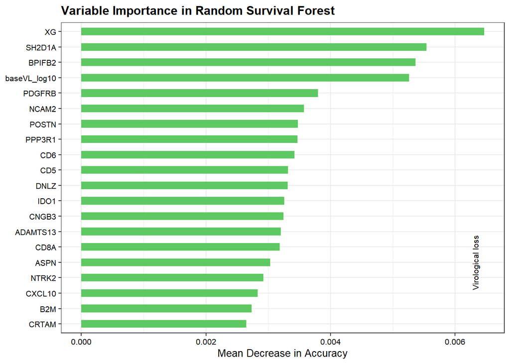

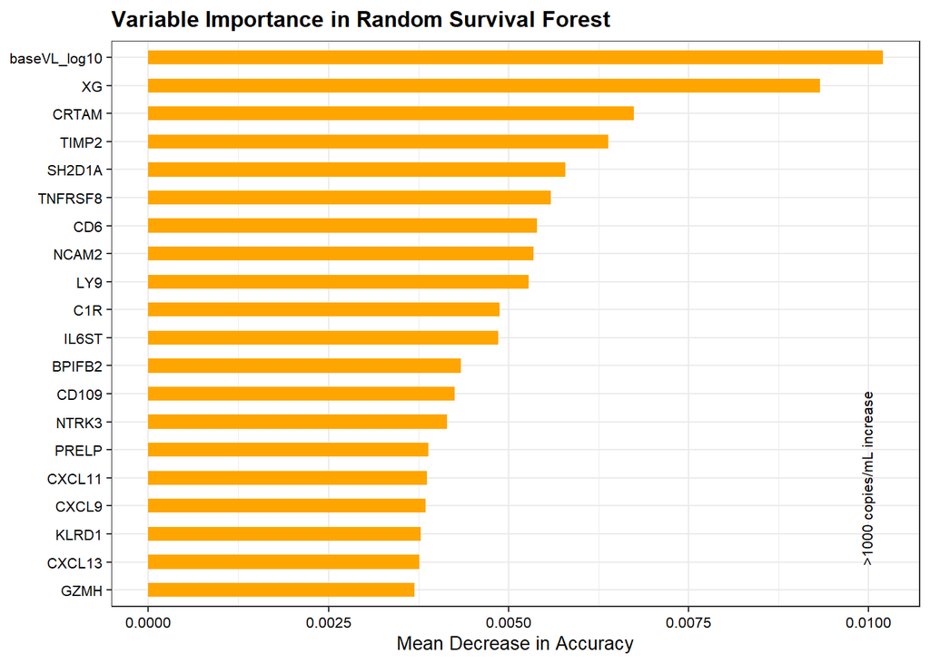

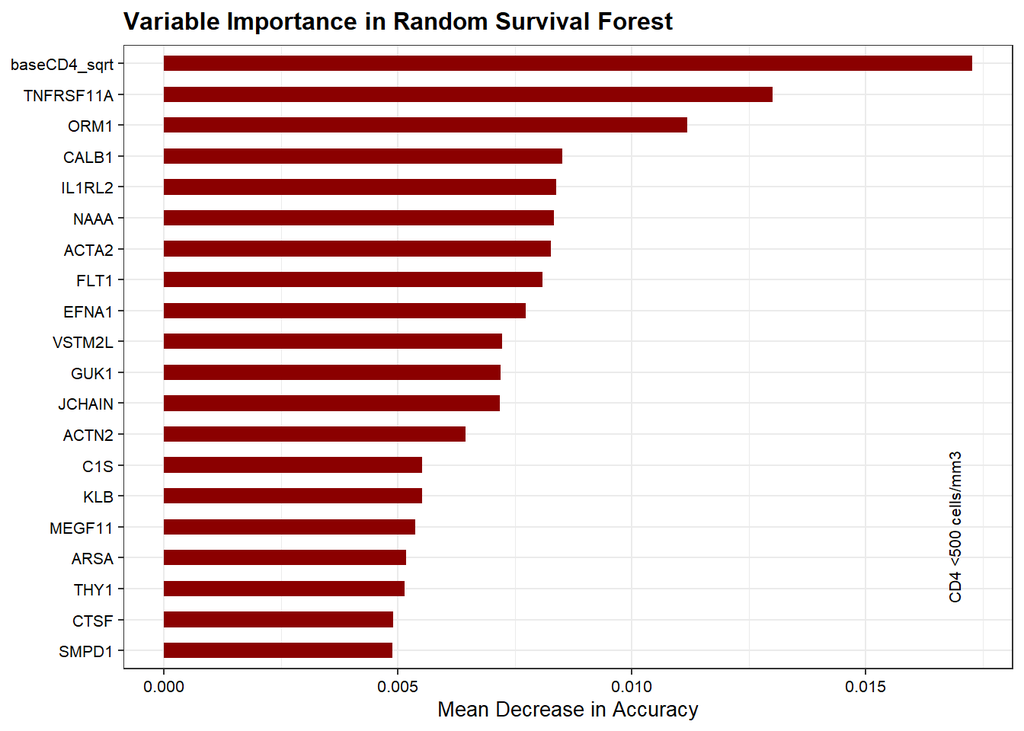

```r
# Make a list of all results
for (outcome in outcomes){
  meandecreaseaccuracy <- obtain_meandecreaseaccuracy(outcome)
}

# Perform cleaning operations on the list
for (outcome in outcomes){
  meandecreaseaccuracy[[outcome]] <- meandecreaseaccuracy[[outcome]] %>%
    mutate(
      Outcome = factor(
        Outcome,
        levels = c("VL4K", "HYBRID", "CD4"),
        labels = c("Virological loss",
                   ">1000 copies/mL increase",
                   "CD4 <500 cells/mm3")))
}

# Create the ggplot
var_importance_plot <- function(outcome_index){
  i <- outcome_index
  data <- meandecreaseaccuracy[[outcomes[i]]] %>%
  arrange(desc(MeanDecreaseAccuracy)) %>% head(20)

  fillcolor <- c("#5ec962","orange","darkred")[i]
  g <- ggplot(data, aes(x = reorder(Variable, MeanDecreaseAccuracy, .desc = TRUE), y = MeanDecreaseAccuracy)) +
  geom_bar(stat = "identity", fill = fillcolor, width = 0.5) +
  coord_flip() +
  labs(title = "Variable Importance in Random Survival Forest",
       x = "Variables",
       y = "Mean Decrease in Accuracy") +
  theme_bw() +
  theme(strip.placement = "outside",
     strip.text = element_text(angle = 0, size = 8),
     strip.background = element_blank(),
     axis.text = element_text(size = 8, color = "black"),
     axis.title.y = element_blank(),
     axis.title.x = element_text(size = 10),
     plot.title = element_text(size = 12, face = "bold")) +

    annotate("text", x = 5, y = max(data$MeanDecreaseAccuracy),
             angle = 90, size = 8 / .pt, vjust = -1,
             label = meandecreaseaccuracy[[outcomes[i]]]$Outcome[1])

  print(g)
}

for (i in c(1:length(outcomes))){
  ggsave(paste0(outputdir, "VariableImportanceRSF_Proteomics_", outcomes[i], ".pdf"),var_importance_plot(i),width = 21/3, height = 29.7/2.75, units = "cm")

}
```

Define a function for the gbm where the formula is statically typed

```r
# outcome <- outcomes[1]
# features <- train[[outcome]] %>% select(-c(time, status, ID)) %>% colnames()
# formula_model <- as.formula(paste("Surv(time, status) ~", paste(features, collapse = " + ")))
# formula_model

obtain_gbmmodel <- function(outcome, dataset_train){
  # Fit a GBM model with survival data
  ## Formula for gbm() has to be statically typed
  if (outcome == "VL4K"){
    gbm_model <- gbm(
        formula = Surv(time, status) ~
          MALESEX + baseVL_log10 + AGE + baseCD4_sqrt +
          GZMH + ITGB1BP2 + ADH4 + EPHX2 + ADAMTS16 + CA5A + ACOX1 +
          MCFD2 + FCRL1 + ADGRG2 + ROR1 + CA13 + CCDC80 + SFTPD + PRKAR1A +
          CDHR5 + IL6ST + GDF2 + NTRK2 + LGALS1 + CDH6 + ADAMTS13 +
          ICAM3 + SELE + CCN3 + LILRB2 + ITGB2 + AMY2A + SEMA7A + XG +
          ADGRE5 + PDGFRB + NCAM1 + OSMR + RARRES2 + NRP1 + ADA2 +
          IGFBP3 + DPP4 + HSPG2 + ENAH + IL17A + IL5 + IL12RB1 + MICB_MICA +
          BID + SCRN1 + PTH1R + ANXA11 + SLAMF7 + IL32 + RAB6A + ITGA6 +
          FCRL6 + SULT2A1 + SH2D1A + KLRB1 + PRDX5 + KLRD1 + CD79B +
          FCRL2 + ADAM23 + CD40LG + IDS + GZMA + CD6 + CD160 + LY9 +
          MZB1 + ENPP5 + CD58 + HSPA1A + CD48 + CCL4 + CXCL10 + CCL17 +
          CXCL9 + TNFRSF13B + CXCL3 + CCL24 + LGALS9 + CD276 + MEGF10 +
          ADGRE2 + CCL22 + PRELP + CA11 + ADCYAP1R1 + NTF4 + NPTN +
          GFER + NAMPT + SUGT1 + FCGR2B + GSTA3 + LTBP3 + FCRLB + RAD23B +
          PSRC1 + HGS + ABL1 + TBC1D23 + MPI + GFRA2 + CALB1 + CDKN1A +
          KAZALD1 + IGF1R + CDNF + KLK13 + USO1 + RBP5 + VAT1 + CDKN2D +
          CD207 + DDAH1 + LAG3 + CBLN4 + PDCD1 + RTN4R + FXN + ITGB7 +
          CD5 + PRDX6 + METAP2 + ITGAV + CLMP + DAB2 + CD27 + PPY +
          C4BPB + ATOX1 + FGFBP1 + ITGB5 + KLB + TST + C19orf12 + CRADD +
          PPP3R1 + ABHD14B + TNFRSF9 + FLRT2 + ASGR1 + GGT5 + ADAM22 +
          CRTAM + CHMP1A + FKBP4 + ROBO2 + SCARF2 + LAMP2 + CD8A +
          CXCL13 + TNFRSF8 + THY1 + CTSS + NTRK3 + SCARA5 + CGA + SPINK5 +
          WARS + IL17RA + NCAM2 + CNTN4 + CD99L2 + CD99 + FCRL5 + NOP56 +
          EXOSC10 + CSF2 + CD2 + SHD + IGHMBP2 + C1GALT1C1 + SIGLEC8 +
          CCER2 + HSBP1 + KHK + NIT1 + GATD3 + ASPN + NIT2 + NGFR +
          BPIFB2 + PGD + RAB27B + LCP1 + COL15A1 + PTPRC + POSTN +
          LATS1 + TNFSF9 + KLRF1 + PTP4A3 + C1QL2 + AKAP12 + SCGB3A1 +
          ADH1B + C1QTNF9 + RIDA + CD72 + GHR + TNFRSF17 + NEXN + C9 +
          F10 + AHSG + AMY1A_AMY1B_AMY1C + B2M + SERPINA5 + IGLC2 +
          C1R + C1S + ORM1 + C3 + DNLZ + CNGB3 + TMCO5A + ERC2 + CABP2 +
          CAMLG + MDM1 + CLGN + EDF1 + RGCC + IDO1 + DSCAM + CDK5RAP3 +
          STXBP1 + TSC22D1 + RGS10 + SUOX + LCN15 + DXO + PLXDC2 +
          PNLIPRP1 + PLCB2 + KLRK1 + KIAA0319 + PALM2 + GSTT2B + DLG4 +
          DHRS4L2 + MINK1 + TXNDC9 + PLSCR3 + VWA5A + LYZL2 + TIGIT +
          REG3G + ZNRF4 + AMOTL2 + ACRBP + FAM171B + TADA3 + TARS1 +
          CHCHD6 + AP3B1 + IFNAR1 + GPHA2 + NFU1,  # Survival formula
        data = dataset_train,
        distribution = "coxph",    # Cox model for survival
        n.trees = 1000,             # Number of trees
        interaction.depth = 3,     # Tree depth
        shrinkage = 0.01,          # Learning rate
        n.minobsinnode = 15,       # Minimum observations in terminal nodes
        bag.fraction = 0.5 # fraction of training data used for fitting, default 0.5
    )
  }else if (outcome == "HYBRID"){
    gbm_model <- gbm(
        formula = Surv(time, status) ~
          MALESEX + baseVL_log10 + AGE + baseCD4_sqrt +
          TSLP + GZMH + CTSH + EDIL3 + ZBTB17 + ADAMTS16 + ACOX1 +
          PRSS27 + SFTPD + CDHR5 + KITLG + IL6ST + GDF2 + LGALS1 +
          IL19 + TNFSF13B + ICAM3 + ITGB2 + PLXNB2 + UMOD + XG + ADGRE5 +
          PDGFRB + PRSS2 + IGFBP3 + HSPG2 + NBN + CLEC4A + CD4 + IL5RA +
          GZMB + LSP1 + PSPN + SH2D1A + BTN3A2 + KLRB1 + CD244 + KLRD1 +
          IL16 + LAMP3 + IL18R1 + CXCL17 + GZMA + CD6 + CD160 + LY9 +
          SCGB1A1 + SIGLEC1 + SMOC2 + CD48 + CCL4 + IL1RN + CXCL9 +
          ANGPTL4 + LGALS9 + MEGF10 + ADGRE2 + PRELP + ADCYAP1R1 +
          UXS1 + DTX3 + GFRA2 + ALPP + LAG3 + PDCD1 + ITGB7 + CD5 +
          SMOC1 + PRTG + FGF23 + CD27 + PPY + KLB + IL34 + NDRG1 +
          NOS3 + S100A16 + DPEP1 + PPP3R1 + SKAP1 + LY96 + PLA2G10 +
          CRTAM + CSF2RA + TNR + EZR + CD8A + CDH15 + SEMA4D + CXCL13 +
          CXCL11 + TNFRSF8 + NTRK3 + IL17RA + NCAM2 + GNLY + CD109 +
          CNTN4 + NOP56 + EXOSC10 + TPR + ENOX2 + DDA1 + CD2 + LRCH4 +
          SNU13 + SART1 + EDEM2 + INPP5D + ANXA2 + ROBO4 + LIPF + ADAMTSL4 +
          GIP + RECK + AAMDC + ASPN + TCOF1 + TIMP2 + CPXM2 + BPIFB2 +
          TPK1 + LCP1 + COL3A1 + PTPRC + POSTN + ITGAL + ZBP1 + TNFSF9 +
          KLRF1 + NECTIN1 + C1QL2 + SCGB3A1 + DIPK2B + MXRA8 + GIMAP7 +
          KLK7 + RLN2 + RNASE4 + APOL1 + CFHR2 + B2M + IGLC2 + C1R +
          MBL2 + KLF4 + CNGB3 + IMPG1 + PMS1 + PPT1 + TPSD1 + SAFB2 +
          REEP4 + DNPEP + PNLIPRP1 + ZHX2 + KLRK1 + C7orf50 + YAP1 +
          GBP1 + CEACAM20 + NEK7 + TIGIT + WDR46 + BTN1A1 + GLYR1 +
          DYNLT3 + NENF + IL2RG + GPD1 + DYNC1H1 + NACC1 + RALY + CEACAM19 +
          ATRAID + SWAP70 + BCL2 + LMNB1 + SMNDC1 + IFI30,  # Survival formula
        data = dataset_train,
        distribution = "coxph",    # Cox model for survival
        n.trees = 1000,             # Number of trees
        interaction.depth = 3,     # Tree depth
        shrinkage = 0.01,          # Learning rate
        n.minobsinnode = 15,       # Minimum observations in terminal nodes
        bag.fraction = 0.5 # fraction of training data used for fitting, default 0.5
    )

  }else if (outcome == "CD4"){
    gbm_model <- gbm(
        formula = Surv(time, status) ~
          MALESEX + baseVL_log10 + AGE + baseCD4_sqrt +
          VSTM2L + MSTN + ACTA2 + DDC + MARCO + SORT1 + FBP1 + ICAM3 +
          MFAP5 + FABP4 + FUCA1 + VASN + C2 + IGFBP6 + HSPG2 + JCHAIN +
          IL1RL2 + AMBN + LRRN1 + FCRL3 + AMN + CNTNAP2 + CLEC4A +
          PTX3 + LY75 + CLEC4G + KLRB1 + TNFRSF11A + LY9 + SCGB1A1 +
          MZB1 + CCL4 + FST + RRM2 + CFC1 + RARRES1 + SERPINA9 + CALB1 +
          GPA33 + OPTC + CCN1 + FLT1 + LAG3 + RTN4R + AMBP + CD300LF +
          HSPB6 + CRISP2 + KLK6 + NELL1 + C4BPB + LYPD3 + KLK1 + CTSF +
          KLB + NXPH1 + VSTM1 + NOS3 + PAK4 + WFIKKN1 + CRTAM + VWC2 +
          FUT8 + NAAA + DKK1 + SEMA4D + THY1 + SMPD1 + SPINK5 + PIK3IP1 +
          DSG2 + EFNA1 + FCRL5 + ARSA + MEGF11 + CPTP + GUK1 + ACTN2 +
          SIGLEC8 + HRC + ROBO4 + CCER2 + LAMB1 + ECHDC3 + MAN2B2 +
          BPIFB2 + FABP3 + GOT1 + CYTL1 + C1QL2 + AKAP12 + CST1 + C9 +
          AMY1A_AMY1B_AMY1C + SHBG + CFD + C1R + C1S + SELENOP + ORM1 +
          DTX2 + IDO1 + MCEE + DNPEP + CDH23 + VWA5A + TIGIT + CASP4 +
          RNF43,  # Survival formula
        data = dataset_train,
        distribution = "coxph",    # Cox model for survival
        n.trees = 1000,             # Number of trees
        interaction.depth = 3,     # Tree depth
        shrinkage = 0.01,          # Learning rate
        n.minobsinnode = 15,       # Minimum observations in terminal nodes
        bag.fraction = 0.5 # fraction of training data used for fitting, default 0.5
    )

  }else{warning("Unrecognized outcome type")}

  return(gbm_model)
}

outcome <- outcomes[1]
gbm_model <- obtain_gbmmodel(outcome, dataset_train)
```

```r
# Define outcome measures
outcomes <- c("VL4K","HYBRID", "CD4")

# Specify time points of interest to measure AUC
times <- seq(2, 8) * 365

# Define function to get score result
## This function will be used in the function obtain_auc below
obtain_scores <- function(models_list, dataset, survformula, traintest){
  score_result <- Score(models_list,
        formula = survformula,
        data = dataset,
        metrics = "auc",
        summary = "risks",
        times = times,
        plots = "ROC")

  AUC_overtime <- score_result$AUC$score
  AUC_overtime$type <- traintest

  ROC_overtime <- score_result$ROC$plotframe
  ROC_overtime$type <- traintest

  AUCROC_overtime <- list(AUC_overtime = AUC_overtime, ROC_overtime = ROC_overtime)

  return(AUCROC_overtime)
}

# Define function to get the AUC over time
obtain_aucroc <- function(outcome, metric){
  if (metric %notin% c("AUC", "ROC")) {
    stop("Invalid metric! Metric must be either 'AUC' or 'ROC'")
  }
  if (outcome %notin% c("VL4K", "HYBRID", "CD4")) {
    stop("Invalid outcome! Metric must be one of: VL4K, HYBRID, CD4")
  }

  # Add CD6 and others for CD4 outcome, since these were not significant for CD4 outcome
  if ("CD6" %notin% colnames(train[[outcome]])){
    dataset_train <- train[[outcome]] %>% filter(!is.na(status)) %>% left_join(
      train[["VL4K"]] %>% select(ID, CD6, SH2D1A, CNGB3), by = "ID")
    dataset_test <- test[[outcome]] %>% filter(!is.na(status)) %>% left_join(
      test[["VL4K"]] %>% select(ID, CD6, SH2D1A, CNGB3), by = "ID")
  }else{
    dataset_train <- train[[outcome]]
    dataset_test <- test[[outcome]]
  }

  # Train the cox model
  formula_model_small <- as.formula(paste("Surv(time, status) ~", paste(c(clinicalpredictors, proteomic_selection), collapse = " + ")))

  coxmodel <- coxph(formula_model_small, dataset_train, x = TRUE)

  # Define the formula for other models
  features <- train[[outcome]] %>% select(-c(time, status, ID)) %>% colnames()
  formula_model <- as.formula(paste("Surv(time, status) ~", paste(features, collapse = " + ")))

  # Train the elastic-net (balanced) penalized cox model
  elasticnetcox_model <- GLMnet(
    formula = formula_model,
    data = dataset_train,
    alpha = 1,
    lambda = NULL,
    cv = TRUE,
    nfolds = 10,
    standardize = TRUE)

  # train the RSF, random survival forest
  rsfmodel <- rfsrc(formula_model, data = dataset_train, ntree = 3000, cv.fold = 10, nodesize = 15, mtry = 4, splitrule = "logrankscore", nsplit = 10)

  # Fit a GBM model with survival data
  gbm_model <- obtain_gbmmodel(outcome = outcome,
                               dataset_train = dataset_train)

  # Calculate AUC data over time for train and test
  survformula <- as.formula(paste("Surv(time, status) ~ 1"))
  model_list <- list("Cox" = coxmodel,
                     "RSF" = rsfmodel,
                     "GBM" = gbm_model,
                     "ElasticNetCox" = elasticnetcox_model)
  auc_train <- obtain_scores(model_list, dataset_train, survformula, "train")$AUC_overtime
  auc_test <-  obtain_scores(model_list, dataset_test, survformula, "test")$AUC_overtime

  auc_combined <- rbind(auc_train, auc_test)
  auc_combined$outcome <- outcome

  roc_train <- obtain_scores(model_list, dataset_train, survformula, "train")$ROC_overtime
  roc_test <-  obtain_scores(model_list, dataset_test, survformula, "test")$ROC_overtime

  roc_combined <- rbind(roc_train, roc_test)
  roc_combined$outcome <- outcome

  if (metric == "AUC"){
    return(auc_combined)
  }else if (metric == "ROC"){
    return(roc_combined)
  }else{return(NA)}
}

# Apply the function to each outcome with a lambda function inside map_dfr
auc_data <- map_dfr(outcomes, ~obtain_aucroc(outcome = .x, metric = "AUC"))

roc_data <- map_dfr(outcomes, ~obtain_aucroc(outcome = .x, metric = "ROC"))
```

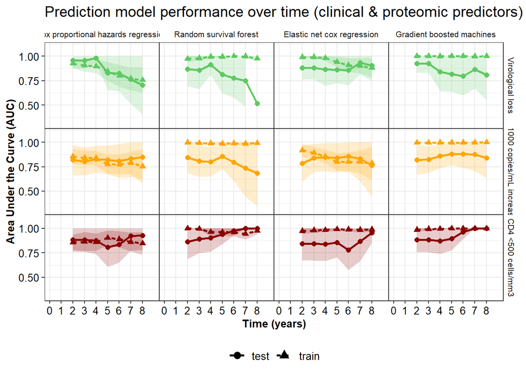

```r
# add nice labels for model and outcome
auc_data <- auc_data %>% mutate(
  model = factor(
    model, levels = c("Cox",
                      "RSF",
                      "ElasticNetCox",
                      "GBM"),
    labels = c("Cox proportional hazards regression",
               "Random survival forest",
               "Elastic net cox regression",
               "Gradient boosted machines")),
  outcome = factor(outcome,
    levels = c("VL4K", "HYBRID", "CD4"),
    labels = c("Virological loss", ">1000 copies/mL increase", "CD4 <500 cells/mm3")))

# Plot AUC over time with confidence intervals
## The plot should facetgrid on model on the x-axis and outcome on the y-axis.
## outcome determines color and fill. type determines shape and linetype and group.
auc_plot <- ggplot(auc_data, aes(x = times, y = AUC, group = type)) +
  geom_line(aes(linetype = type, color = outcome), linewidth = 1) +
  geom_point(aes(shape = type, color = outcome), size = 2) +
  geom_ribbon(aes(ymin = lower, ymax = upper, fill = outcome), alpha = 0.2) +
  labs(x = "Time (years)",
       y = "Area Under the Curve (AUC)",
       title = "Prediction model performance over time (clinical & proteomic predictors)") +
  theme_bw() +
  scale_colour_manual(values=(c("#5ec962","orange","darkred"))) +
  scale_fill_manual(values=(c("#5ec962","orange","darkred"))) +
  scale_y_continuous(limits = c(0.30, 1.1),
    breaks = c(0.5, 0.75, 1.0)) +
  scale_x_continuous(limits = c(0, 9*365),
    breaks = seq(0, max(auc_data$times), by = 365),
    labels = function(x) round(x / 365, 1)
  ) +
  facet_grid(outcome ~ model) +
  theme(strip.placement = "outside",
     strip.text= element_text(angle = 0, size = 8),
     strip.background = element_blank(),
     axis.text = element_text(size = 10, color="black"),
     axis.title = element_text(size = 10, color="black", face = "bold"),
     title = element_text(size=12, color = "black"),
     legend.text = element_text(size = 10, color="black"),
     legend.title = element_blank(),
     legend.position = "bottom",
     plot.subtitle = element_text(size = 10, color= "black", face="italic"),
     #legend.key.height = unit(1.5,'cm'),
     panel.grid.minor.x = element_blank(),
     panel.spacing = unit(0, "mm")) +

  # keep the type legend, but remove the outcome legend
    guides(fill = "none", color = "none", shape = guide_legend(override.aes = list(size=3))) # Remove outcome legend

print(auc_plot)
```

```r
ggsave(paste0(outputdir,"AUC_clinical_and_proteomics.pdf"), plot = auc_plot, width = 210, height = 297/2, units = "mm")
```

# ROC curves

```r
summary.factor(roc_data$model)
```

```
##    Null model           Cox           RSF           GBM ElasticNetCox
##             0          3500          3500          3499          3500
```

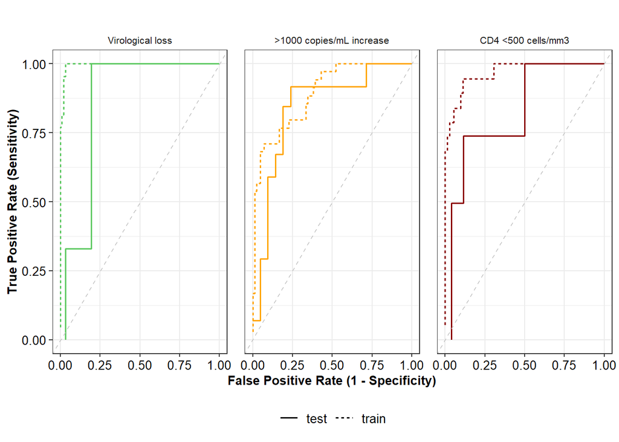

```r
roc_data_5yr <- roc_data %>% filter(times == 3*365) %>%
  filter(model == "ElasticNetCox") %>% mutate(
    outcome = factor(outcome,
      levels = c("VL4K", "HYBRID", "CD4"),
      labels = c("Virological loss", ">1000 copies/mL increase", "CD4 <500 cells/mm3")))

# Plot using ggplot2
roc_plot <- ggplot(roc_data_5yr, aes(x = FPR, y = TPR)) +
  facet_wrap(~ outcome, dir = "h") +
  geom_line(aes(color = outcome, linetype = type), linewidth = 0.65) +
  geom_abline(slope = 1, intercept = 0, linetype = "dashed", color = "grey") +
  scale_colour_manual(values=(c("#5ec962","orange","darkred"))) +
  labs(
    title = "Receiver Operater Curve (ROC) at 3−Year Risk",
    x = "False Positive Rate (1 - Specificity)",
    y = "True Positive Rate (Sensitivity)"
  ) +
  theme_bw()+
    theme(strip.placement = "outside",
     strip.text= element_text(angle = 0, size = 8),
     strip.background = element_blank(),
     axis.text = element_text(size = 10, color="black"),
     axis.title = element_text(size = 10, color="black", face = "bold"),
     title = element_text(size=12, color = "black"),
     legend.text = element_text(size = 10, color="black"),
     legend.title = element_blank(),
     legend.position = "bottom",
     plot.subtitle = element_text(size = 10, color= "black", face="italic"),
     #legend.key.height = unit(1.5,'cm'),
     panel.grid.minor.x = element_blank(),
     panel.spacing = unit(5, "mm")) +

  # keep the type legend, but remove the outcome legend
    guides(fill = "none", color = "none", shape = guide_legend(override.aes = list(size=3))) # Remove outcome legend

print(roc_plot)
```

```r
ggsave(paste0(outputdir,"ROC_clinical_and_proteomics.pdf"), plot = roc_plot, width = 210, height = 297/3, units = "mm")
```